# Algorithms for Quantitative Pedology: a toolkit for digital soil morphometrics

D.E. Beaudette, P. Roudier, J.M. Skovlin

This document is based on `aqp` version 1.8-8

### Why do we need (yet) another framework?

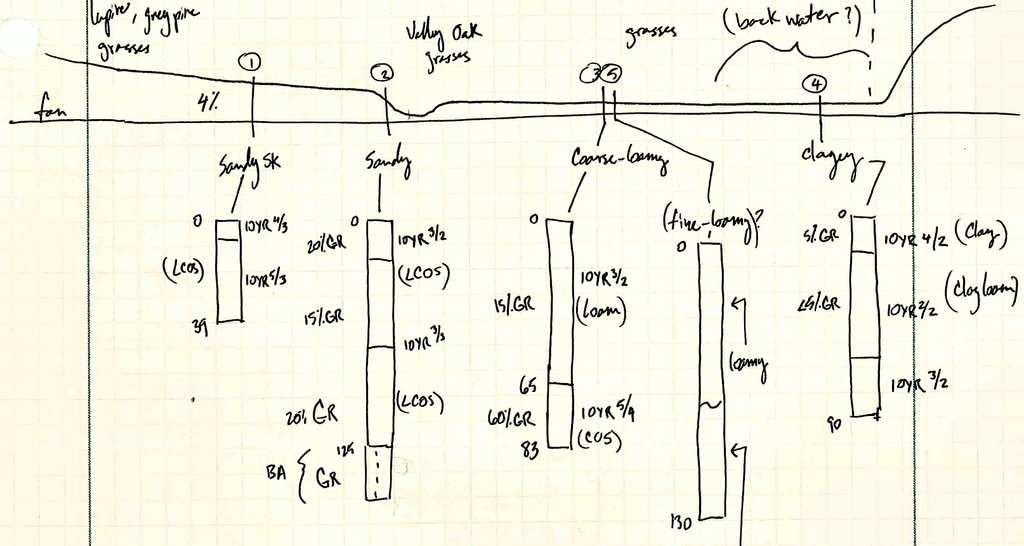

- soil data are complex, inherently visual
- reproducibility is increasingly important
- focus on the interesting questions, not boilerplate
- a common vocabulary for soil data analysis would be nice

### Soil data analysis in theory

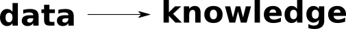

### In practice, it is a long road ...

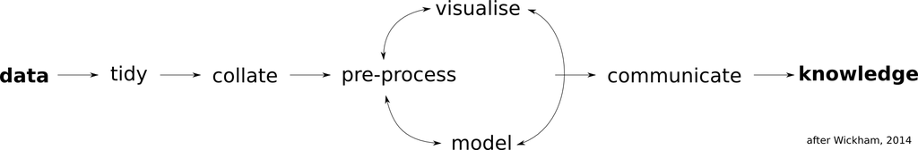

### Improving the workflow

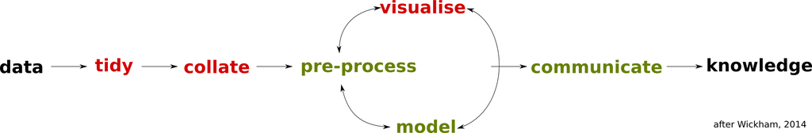

### Why R?

- repeatable, self-documenting work:
  - 2800+ packages on CRAN: 100+ packages on GIS, ecology, and **soils**!
  - package system: algorithms + docs + sample data
- advanced data visualisation capabilities
- algorithm development by experts, application by trained users
  - testing by eye: simple graphical “grammar” used to plot data
  - formalized testing: correlation, regression, classification, ordination, …
  - I/O capabilities: file, URL, SOAP, SQL, ODBC, PDF, PNG, SHP, KML, …
  - optimizers, matrix operations, custom data structures, …

### aqp package: Algorithms for Quantitative Pedology

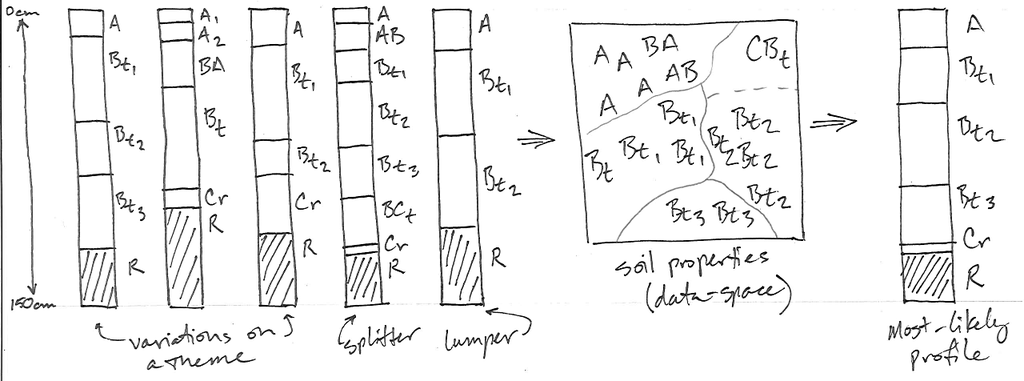

- **special data structures:** avoids annoying book-keeping code
- **visualization:** soil profile sketches, transect diagrams, Munsell → RGB
- **re-sampling:** regular depth-slicing or EA spline (coming soon)
- **aggregation:** summary by depth-slice or arbitrary “slabs”
- **classification:** pair-wise dissimilarity of profiles
- **utility functions:** soil depth, missing data eval., simulation, …

## Details: papers, project homepage

[figure not shown]

[figure not shown]

## This talk: dog and pony show

### SoilProfileCollection objects

```
Formal class 'SoilProfileCollection' [package "aqp"] with 7 slots
  ..@ idcol     : chr "peiid"
  ..@ depthcols : chr [1:2] "hzdept" "hzdepb"
  ..@ metadata  :'data.frame':  1 obs. of  1 variable:
  ..@ horizons  :'data.frame':  308 obs. of  34 variables:
  ..@ site      :'data.frame':  54 obs. of  59 variables:
  ..@ sp        :Formal class 'SpatialPoints' [package "sp"] with 3 slots
  ..@ diagnostic:'data.frame':  177 obs. of  4 variables:
```

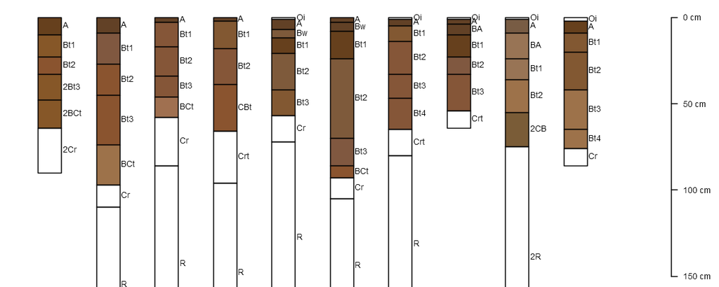

### SoilProfileCollection objects

- object inspection

```r
idname(sp4) # pedon ID name
horizonDepths(sp4) # colum names containing top and bottom depths
depth_units(sp4) # defaults to 'cm'
metadata(sp4) # data.frame with 1 row
profile_id(sp4) # vector of profile IDs
```

- overloads to common functions

```r
length(sp4) # number of profiles in the collection
nrow(sp4) # number of horizons in the collection
names(sp4) # column names from site and horizon data
min(sp4) # shallowest profile depth in collection
max(sp4) # deepest profile depth in collection
sp4[i, j] # get profile "i", horizon "j"
```

- getting / setting of components

```r
horizons(sp4) # get / set horizon data
site(sp4)  # get / set site data
diagnostic_hz(sp4) # get / set diagnostic horizons
proj4string(sp4) # get / set CRS
coordinates(sp4) # get / set coordinates
```

- coercion to `SpatialPointsDataFrame` or `data.frame`

```r
as(sp4, 'SpatialPointsDataFrame')
as(sp4, 'data.frame')
```

### Munsell Color Conversion

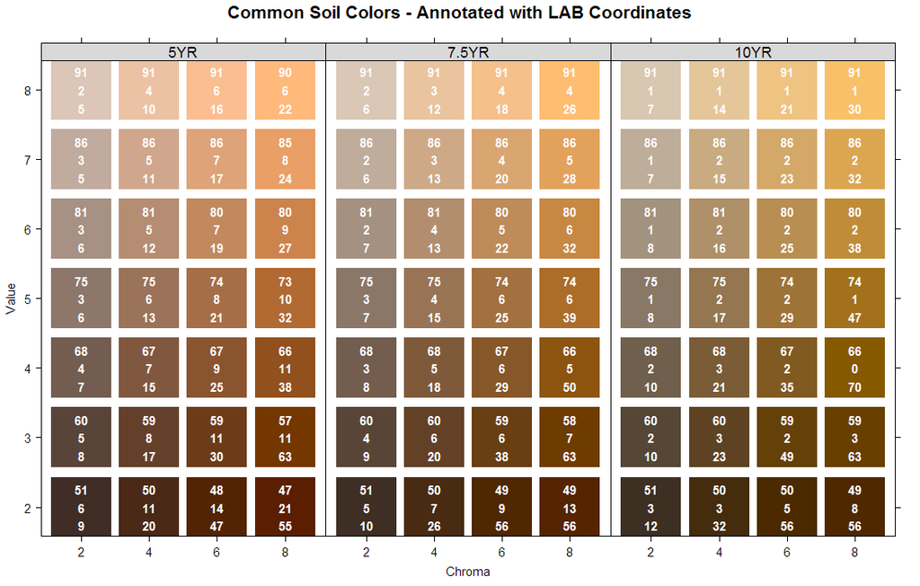

### Plotting SoilProfileCollection Objects

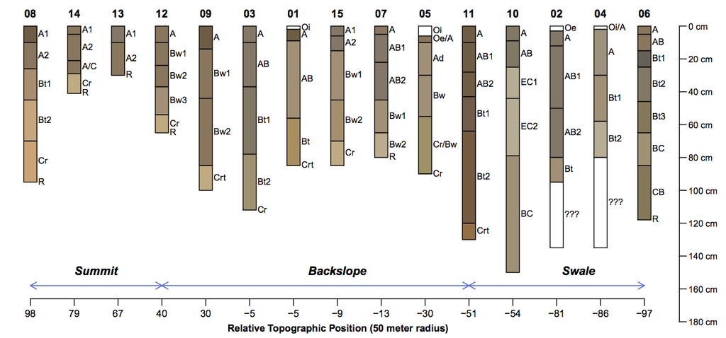

### Plotting SoilProfileCollection Objects

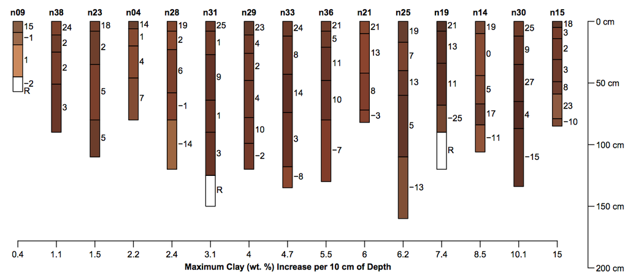

### Plotting SoilProfileCollection Objects

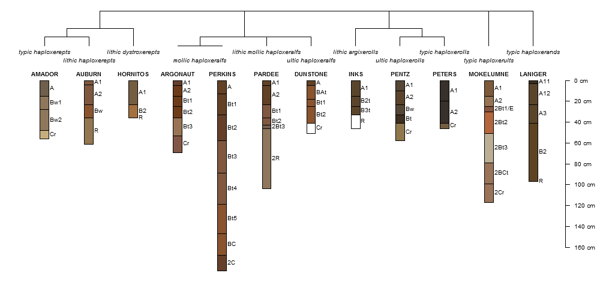

### Plotting SoilProfileCollection Objects

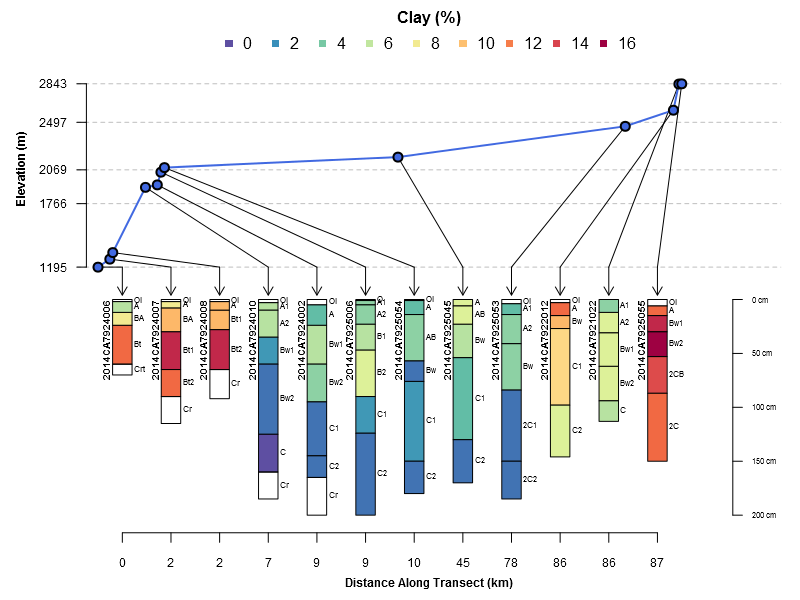

### Plotting SoilProfileCollection Objects

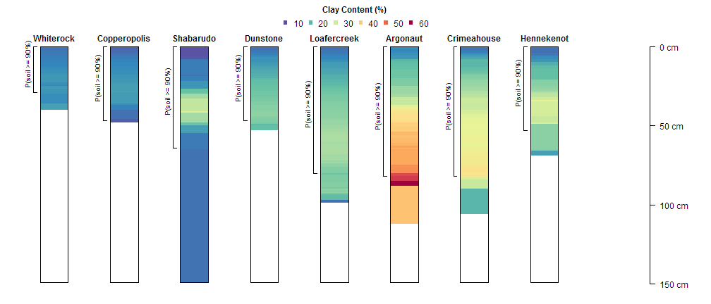

### Slice-Wise Aggregation: RIC via quantiles

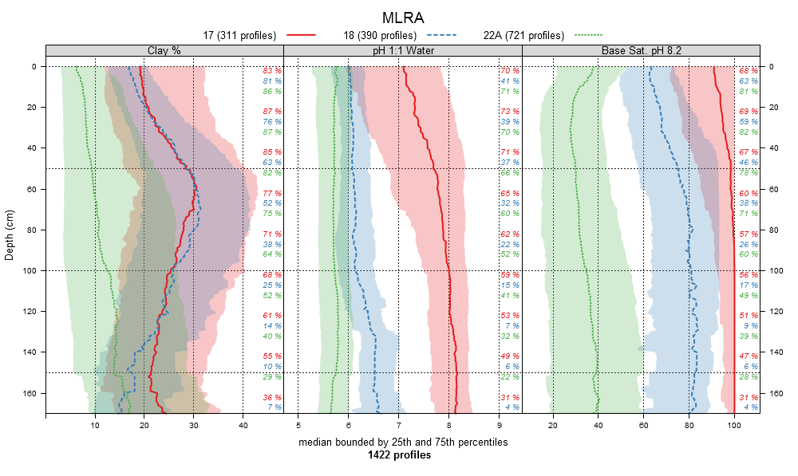

### Slice-Wise Aggregation: RIC via quantiles

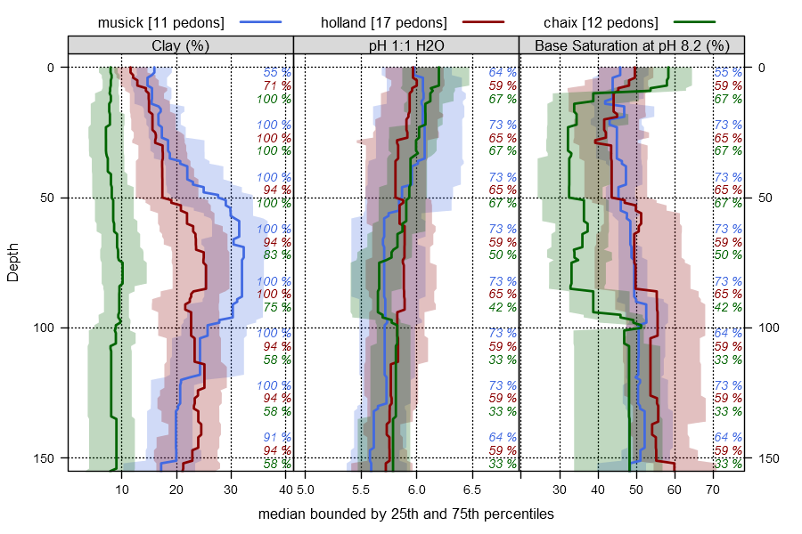

### Slice-Wise Aggregation: RIC via quantiles

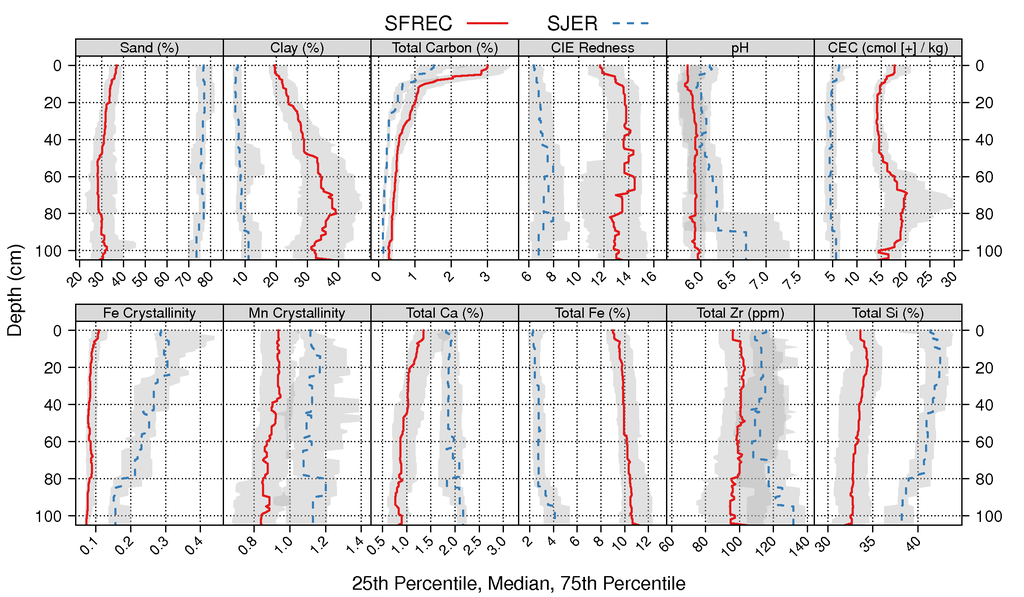

### Slice-Wise Aggregation: probabilities

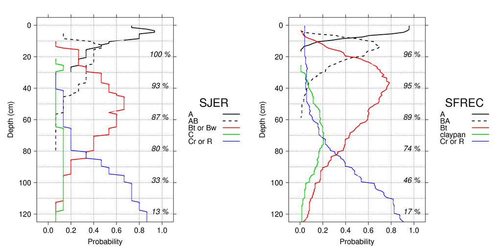

### Slice-Wise Aggregation: probabilities

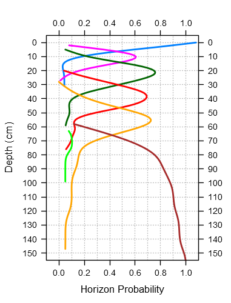

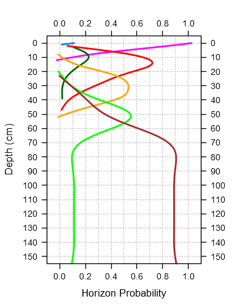

### Pair-Wise Dissimilarity

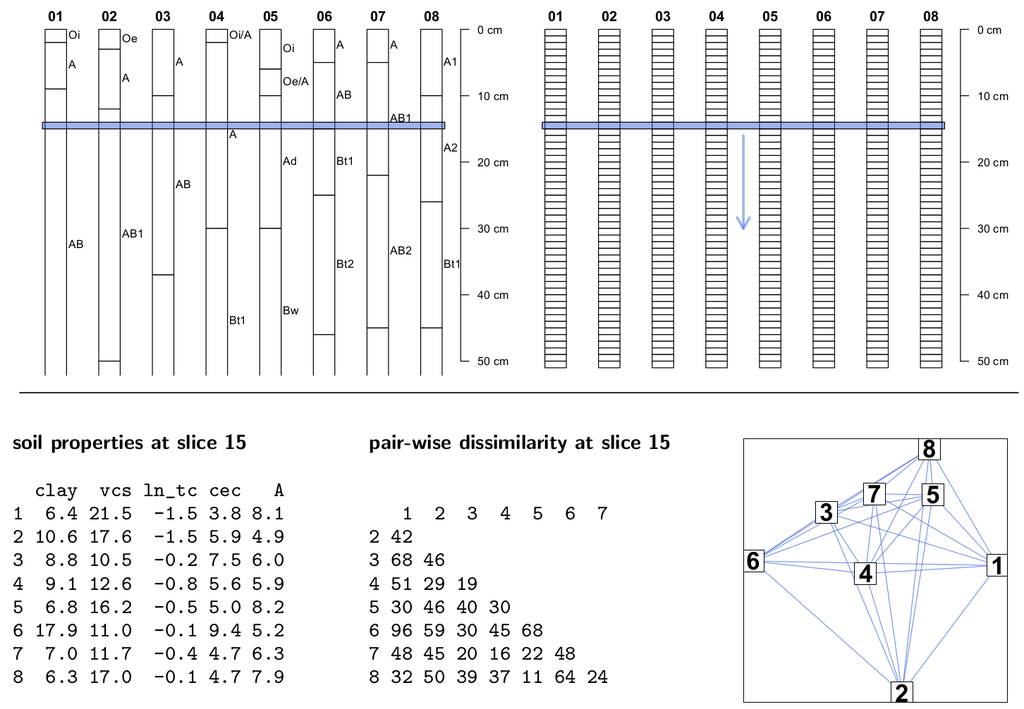

### Pair-Wise Dissimilarity

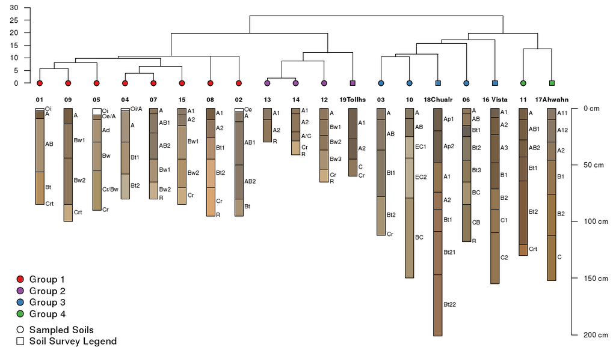

### Recent (last hour) developments, inspired group discussion

- inspired by Darrell et al. (thanks Pierre)
  - depiction of structure|fabric via unconditional sim. (variogram)
  - not perfect, but illustrates rapid protoyping framework

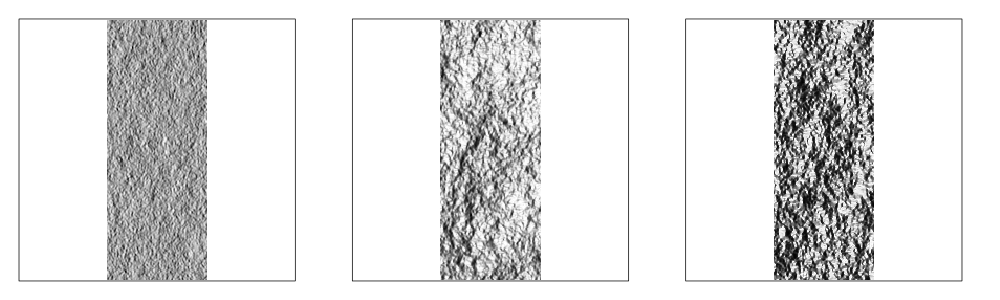

- on deck for next week (thanks Pierre)
  - more efficient `SoilProfileCollection` implementation + images
  - EA spline methods for `SoilProfileCollection`
  - integration of hz boundary topography / distinctness into sketches

### Concluding remarks

- **managing soils data** can be difficult and time-consuming
- DSM requires considerable **data processing**
- DSM requires detailed **analysis** of soil profile collections or aggregate soils data

## AQP can help:

- simple conversion from common data sources to SoilProfileCollection
- SoilProfileCollection objects are powerful
- innovative constructs: `slice()`, `slab()`, `SPC[i,j]`
- pair-wise dissimilarity: `profile_compare()`
- visual comparisons and non-parametric summaries

**AQP speaks digital soil morphometrics**

Thank You!

http://aqp.r-forge.r-project.org